# STAT/MATH 495: Problem Set 09

Caleb Brooks

2017-11-07

# Collaboration

Please indicate who you collaborated with on this assignment:

# Question 1: Run k-means

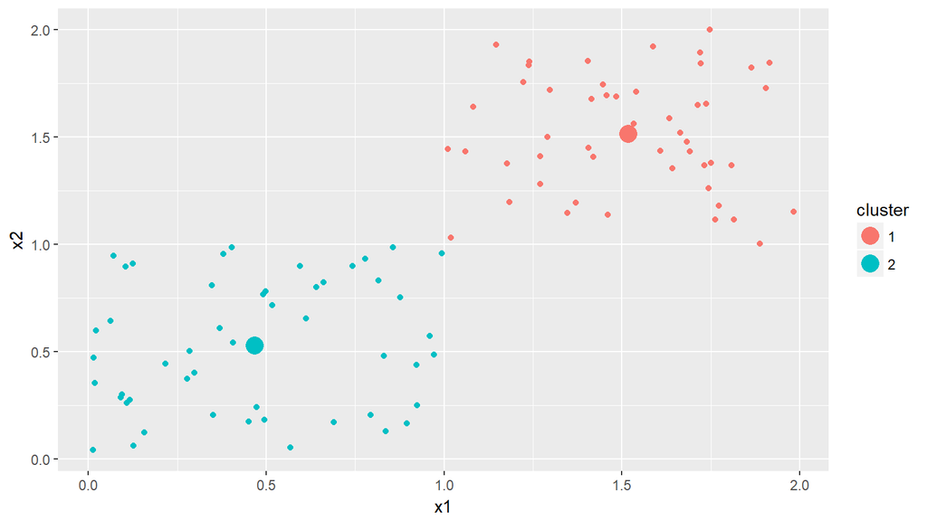

```r
observations_1 <- read_csv("data/observations_1.csv")
observations_2 <- read_csv("data/observations_2.csv")

# Set observations to be one of two datasets
observations <- observations_2

# Fit model for k=2
k <- 2
k_means_results <- kmeans(observations, centers=k)
clusters <- k_means_results$cluster
cluster_centers <- k_means_results$centers

# Add cluster results to observations. Note we convert to factor since cluster
# ID's should be treated as categorical
observations$cluster <- as.factor(clusters)

# Add cluster ID's to cluster_centers
cluster_centers <- cluster_centers %>%
  as_tibble() %>%
  mutate(cluster=as.factor(1:k))

ggplot(NULL, aes(x=x1, y=x2, col=cluster)) +
  geom_point(data=observations) +
  geom_point(data=cluster_centers, size=5)
```

**Questions**:

1. Run KMC 10 times on `observations_1` and comment on the consistency of the results.

Results are consistently different. The difference could be visually described as the total set being bisected as different angles on each iteration.

1. Speculate on the root cause of any consistency or inconsistency in the results.

The data are not actually clustered, or at least do not visually appear to be, and thus there is some randomness to the KMC results, which stems from the fact that in the initialization step of KMC the groupings are randomly assigned, and thus the center of each grouping tends toward a random spot in the uniformly-distributed data.

1. Run KMC 10 times on `observations_2` and comment on the consistentcy of the results.

The results are the same each time

1. Speculate on the root cause of any consistency or inconsistency in the results.

The data are distinctly clustered, and so the results of KMC are always the same - the randomness of the initialization is negated by the lack of randomness in the clustering of the data.

# Bonus question: Code your own

```r
# Hint:
library(proxy)
A <- data_frame(
  x1 = c(0, 0.5, 0.75, 1),
  x2 = c(0, 0.5, 0.75, 1)
)
B <- data_frame(
  x1 = c(1, 0),
  x2 = c(1, 0)
)
distance_matrix <- proxy::dist(x=A, y=B)
distance_matrix
```

```
##      [,1]      [,2]
## [1,] 1.4142136 0.0000000
## [2,] 0.7071068 0.7071068
## [3,] 0.3535534 1.0606602
## [4,] 0.0000000 1.4142136
```

```r
apply(distance_matrix, 1, which.min)
```

```
## [1] 2 1 1 1
```